# Gráficos e Mapas Interativos no R

GGplot2

Graficos

R

Mapas

Autores

Ana Li

Gabriel Gonçalves

**Orientador:** Rafael Erbisti

# **Interatividade nos gráficos feitos pelo ggplot**

As bases e gráficos usados abaixo foram retirados da segunda oficina.

```r
library(tidyverse)
library(plotly)

performance = read_csv("bases/student_habits_performance.csv")
performance = performance %>%
    filter(gender != "Other")
```

O `ggplotly()` é uma função do pacote `plotly` que converte um gráfico criado com ggplot2 em um gráfico interativo do Plotly.

Principais parâmetros do ggplotly():

- `p` : O objeto ggplot que será convertido para Plotly.
- `tooltip` : Define quais variáveis aparecerão no tooltip (dica de informação ao passar o mouse).
- `dynamicTicks` : Se TRUE, os eixos se ajustam dinamicamente ao zoom.

Peguemos de exemplo um gráfico feito na segunda oficina do projeto DataViz.

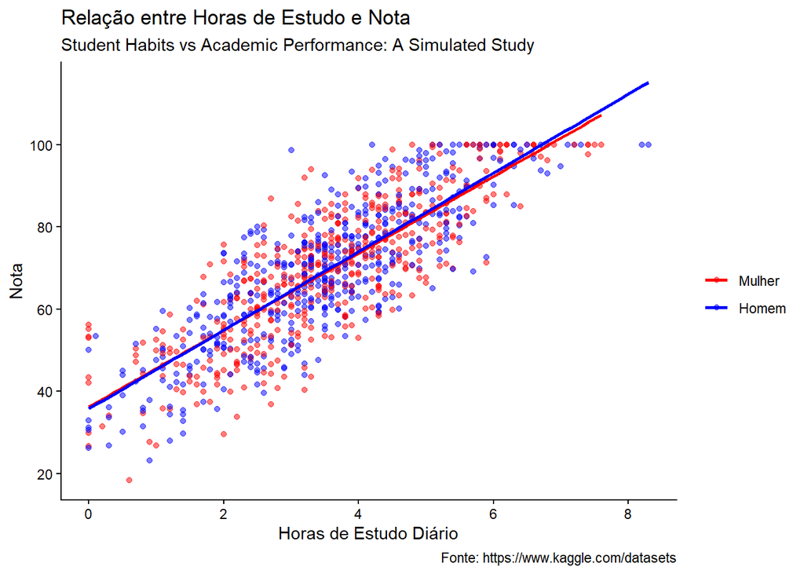

```r
graf1 = performance %>%
  ggplot(aes(x = study_hours_per_day, y = exam_score, color = gender)) +
  geom_point(alpha = 0.5)+
  geom_smooth(method='lm',se = F)+
  scale_y_continuous(breaks = seq(0, 100, 20))+
  scale_color_manual(values = c("Red","Blue"),
                     labels = c("Mulher","Homem"))+ # mudando o nome das categorias
  labs(x = "Horas de Estudo Diário", y = "Nota" ,color = "" ,
       title = "Relação entre Horas de Estudo e Nota",
       subtitle = "Student Habits vs Academic Performance: A Simulated Study",
       caption = "Fonte: https://www.kaggle.com/datasets") +
  theme_classic()

graf1
```

```r
ggplotly(graf1)
```

[interactive chart not shown]

Perceba que detalhes como subtítulo, a legenda e os textos estão diferentes. Quando a função `ggplotly()` é utilizada, nem todas as modificações feitas anteriormente serão mantidas.

Uma forma de solucionar esse problema é usando a função `layout()` do `plotly` que controla o aspecto geral do gráfico, como títulos, eixos, legendas, margens e anotações.

```r
# transformando os dados antes de plotar

performance = performance %>%
  mutate(gender = case_when(
    gender == "Female" ~ "Mulher",
    gender == "Male" ~ "Homem",
    TRUE ~ as.character(gender)
  ))

# gráfico modificado

graf1_mod = performance %>%
    ggplot(aes(x = study_hours_per_day, y = exam_score, color = gender)) +
    geom_point(alpha = 0.5,
               aes(text = paste0("Horas de Estudo: ", study_hours_per_day,
                                 "<br>",
                                 "Nota: ", exam_score,
                                 "<br>",
                                 "Sexo: ", gender,
                                 "<br>",
                                 "Horas de Sono: ", sleep_hours)))+
    geom_smooth(method='lm',se = F)+
    scale_y_continuous(breaks = seq(0, 100, 20))+
    scale_color_manual(values = c("Red","Blue"))+ # mudando o nome das categorias
    labs(x = "Horas de Estudo Diário", y = "Nota" ,color = "" ,
         title = "Relação entre Horas de Estudo e Nota") +
    theme_classic()

ggplotly(graf1_mod,
         tooltip = "text",# a informação do hover será a do text do geom_point
         dynamicTicks = TRUE)%>% # ajuste dos eixos
  layout(hoverlabel=list(bgcolor = "#ffffff"), # definindo cor do fundo do hover
         title = "<b>Relação entre Horas de Estudo e Nota</b><br><sub>Student Habits vs Academic Performance: A Simulated Study</sub>", # título e subtítulo
          legend = list(
            title = list(text = "Sexo"), # título da legenda
            x = 0.8,  # posição da legenda no layout
            y = 0.1,
            orientation = "v" # categorias na vertical
          )
        )
```

[interactive chart not shown]

# **Leitura e manipulação de arquivos shapefile**

Shapes são arquivos que contém coordenadas geográficas que podem ser transformadas em mapas. Esses arquivos podem ser retirados do site do Instituto Brasileiro de Geografia e Estatística (IBGE) ou do pacote `geobr` por exemplo.

Para importar shapefile, utiliza-se a função `st_read()` do pacote `sf`. Para que a leitura do arquivo shapefile funcione corretamente, todos os arquivos auxiliares devem estar na mesma pasta do diretório.

- **.shp** - O arquivo que armazena a geometria dos elementos (obrigatório);
- **.shx** - O índice da geometria dos elementos (obrigatório);
- **.dbf** - A tabela de atributos em formato dBASE, que contém informações descritivas dos elementos (obrigatório);
- Outros arquivos opcionais podem fornecer informações adicionais como projeção e codificação de caracteres.

```r
if (!require("sf")) install.packages("sf")
library(sf)

# lendo o shapefile dos municípios do Rio de Janeiro
RJshape = st_read("shapes/RJ_Municipios_2024/RJ_Municipios_2024.shp", options = "ENCODING=UTF-8")
```

```
options:        ENCODING=UTF-8
```

```r
# Forma alternativa:

if (!require("geobr")) install.packages("geobr")
library(geobr)

RJshape = read_municipality(code_muni = "RJ", year = 2024)

# Filtrar apenas Niterói:

nit_shape <- RJshape %>%
    filter(name_muni == "Niterói")
```

# **Criação de mapas com ggplot2 e geom_sf**

Existem diversas maneiras de criar mapas no R, uma delas é através da função `geom_sf()` do pacote `ggplot2`. A função detecta a informação geométrica dos objetos `sf` para desenhar o mapa.

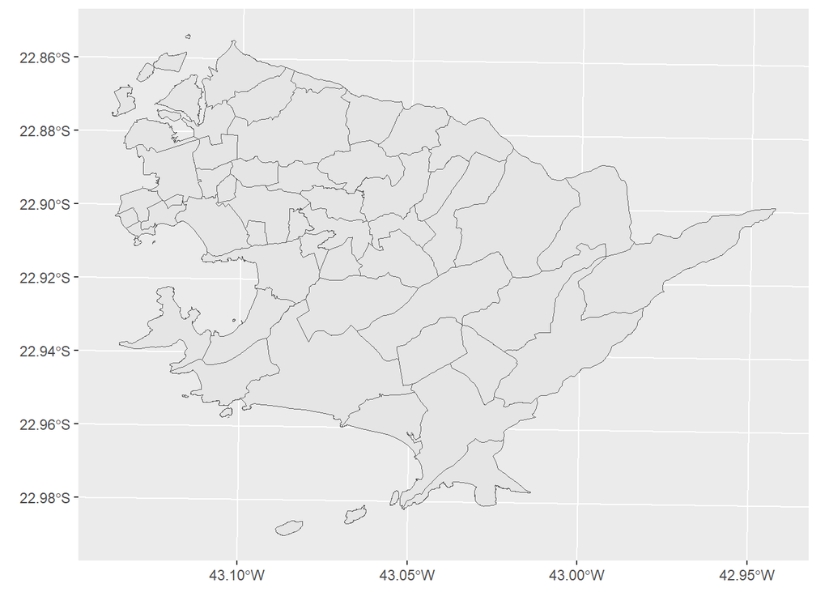

```r
# lendo o shapefile dos bairros de Niterói
bairros = st_read("shapes/BairrosNit/Limite_de_Bairros.shp")
# Mapa vazio
ggplot(bairros) + geom_sf()
```

## **Transformação de coordenadas**

Os dados espaciais podem vir em diversos sistemas de referência de coordenadas (CRS). Então, até mesmo antes de plotar os mapas, precisamos verificar se as coordenadas dos dados possuem o mesmo CRS. Caso contrário, as coordenadas precisam ser transformadas para evitar problemas de desalinhamento, distorção, erros de projeção,etc.

A função utilizada para transformar coordenadas é `st_transform()`. Basta inserir o objeto `sf` e o `crs` de interesse como argumentos da função.

```r
# lendo pontos
escolas = read_csv('bases/Escolas_Municipais_de_Ensino_Fundamental.csv')
escolas
```

```
# A tibble: 49 × 14
         X       Y tx_bairro tx_email tx_endereco tx_escola tx_tipo tx_anos_2022
     <dbl>   <dbl> <chr>     <chr>    <chr>       <chr>     <chr>   <chr>
 1 695495.  7.47e6 Engenhoca emadeli… "R. Dr. Ne… E.M. Ade… Ensino… 3 a 5 anos;…
 2 694965.  7.47e6 Barreto   emaltiv… "R. Dr. Lu… E.M. Alt… Ensino… 3º e 4º cic…
 3 692060.  7.47e6 São Domi… emanisi… "Trav. Man… E.M. Aní… Ensino… 1º e 2º cic…
 4 698492   7.47e6 Caramujo  emantin… "Rodovia A… E.M. Ant… Ensino… 3º e 4º cic…
 5 700470.  7.47e6 Santa Bá… emanton… "R.Nestor … E.M. Ant… Ensino… 1º e 2º cic…
 6 692991.  7.47e6 Morro do… emayrto… "R. Altami… E.M. Ayr… Ensino… 1º e 2º cic…
 7 694999   7.47e6 Fonseca   emdemen… "Trav. Mag… E.M. Dem… Ensino… 4 a 5 anos;…
 8 702064.  7.47e6 Maria Pa… emdioge… "Est. Caet… E.M. Dió… Ensino… 5 anos; 1º …
 9 697227   7.47e6 Fonseca   emdjalm… "R. Cinco … E.M. Dja… Ensino… 1º e 2º cic…
10 695726.  7.47e6 Fonseca   emdomjo… "R. Tenent… E.M. Dom… Ensino… 1º e 2º cic…
# ℹ 39 more rows
# ℹ 6 more variables: globalid <chr>, tx_regiao <chr>, tx_turno <chr>,
#   tx_modalidade <chr>, objectid <dbl>, tx_telefone <chr>
```

```r
# criando objeto sf com as coordenadas em UTM
pontos_utm = st_as_sf(
  escolas, #
  coords = c("X", "Y"),
  crs = 31983 # EPSG
)

#transformando dados em UTM para lat/long
pontos_latlong = st_transform(pontos_utm, crs = 4674)

#matriz com coordenadas
coordenadas = st_coordinates(pontos_latlong)

#adicionando colunas com as coordenadas no data.frame pontos_nit
pontos_nit = escolas %>% mutate(LONGITUDE = coordenadas[,1],
                                       LATITUDE = coordenadas[,2])
```

## **Mapa de pontos**

É possível apresentar mais de uma informação geométrica em um único mapa. Existem duas formas de plotar os pontos no mapa:

- `geom_sf()` com o objeto sf
- `geom_point()` com as coordenadas nos eixos

[figure not shown]

```r
# filtrando apenas o município de Niterói
nit_shape = RJshape %>%
    filter(NM_MUN == "Niterói")

# com geom_point():

ggplot(nit_shape) + geom_sf() + geom_point(data = pontos_nit, aes(x = LONGITUDE,
    y = LATITUDE)) + theme_minimal()
```

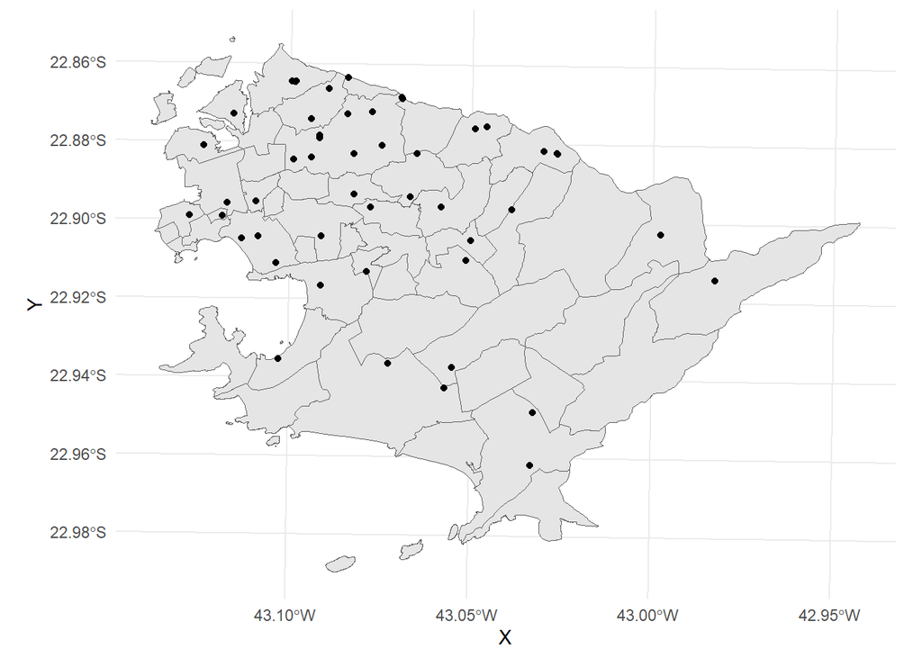

```r
ggplot(bairros) + geom_sf() + geom_point(data = pontos_nit, aes(x = X, y = Y)) +
    theme_minimal()
```

> Perceba que ao usar nit_shape (que está em graus) os pontos são mapeados através das colunas LONGITUDE e LATITUDE que correspondem às coordenadas em graus. Quando usamos bairros, os pontos são mapeados através de X e Y que correpondem às coordenadas UTM.

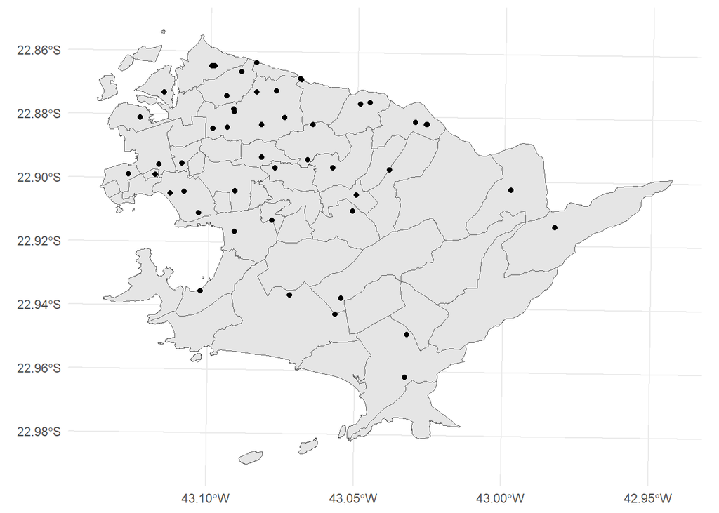

```r
# com geom_sf():
ggplot() + geom_sf(data = bairros) + geom_sf(data = pontos_utm) + theme_minimal()
```

A forma de modificar a estética do mapa é a mesma para todos os `geoms`.

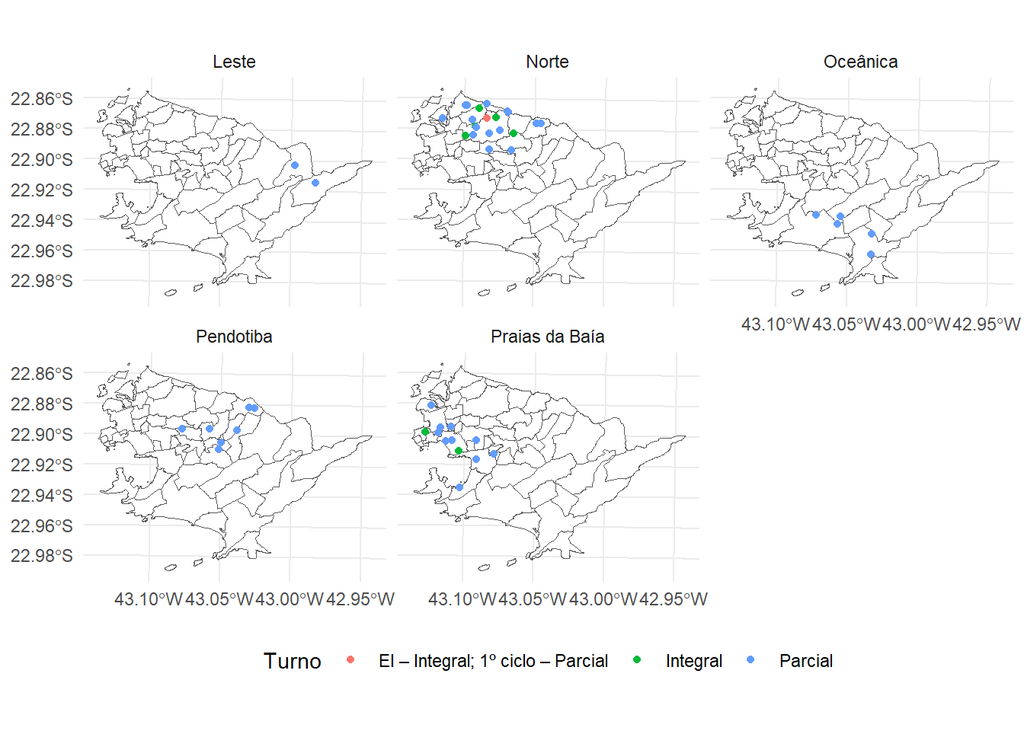

```r
ggplot()+
  geom_sf(data = bairros,fill='white')+ # plotagem do município de Niterói
  geom_sf(data = pontos_utm, # plotagem dos pontos
          aes(col=tx_turno))+ # pontos coloridos de acordo com o turno
  facet_wrap(~tx_regiao)+ # facetas por região
  labs(color = 'Turno')+
  theme_minimal()+
  theme(legend.position = 'bottom') # legenda para baixo
```

## **Mapa Coroplético**

Para apresentar observações de uma variável de interesse em uma determinada área, é preciso integrar as informações da variável com a geometria do shapefile através de um `_join`. Como a base inicial é o shape, a base resultante precisa ter as mesmas linhas. A variável **link**, que pode ser o nome ou código do local, tem que estar presente em ambas as bases e precisa ser de classes iguais.

```r
# lendo a base de taxa de mortalidade bruta no RJ
taxaRJ = read_csv2("bases/taxa_mortRJ.csv", locale = locale(encoding = "latin1"))

# juntando as duas bases para formar um único objeto sf
taxa_shape = RJshape %>%
    left_join(taxaRJ, by = c(NM_MUN = "Município"))
```

Com a base integrada pronta, é possível plotar o mapa coroplético.

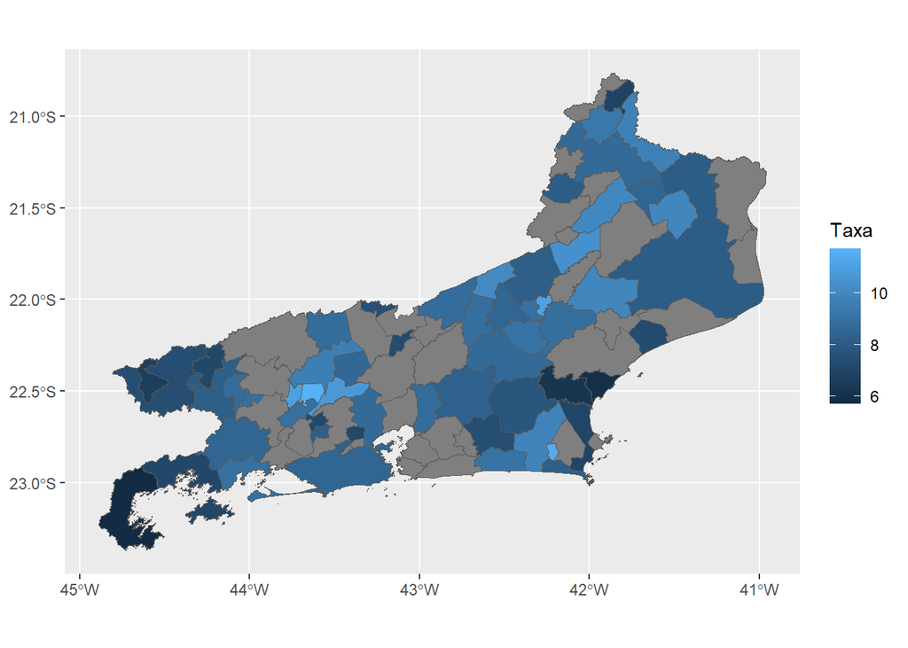

```r
# taxa de mortalidade por município RJ
taxa_shape %>%
    ggplot(aes(fill = Total)) + geom_sf() + labs(fill = "Taxa")
```

De forma análoga aos gráficos vistos na segunda oficina, é possível personalizar as cores dos polígonos dos mapas com funções `scale_fill_`. No entanto, para inserir textos, de acordo com objetos `sf`, utilize as funções `geom_sf_text()` ou `geom_sf_label()` ao invés do `geom_text()`.

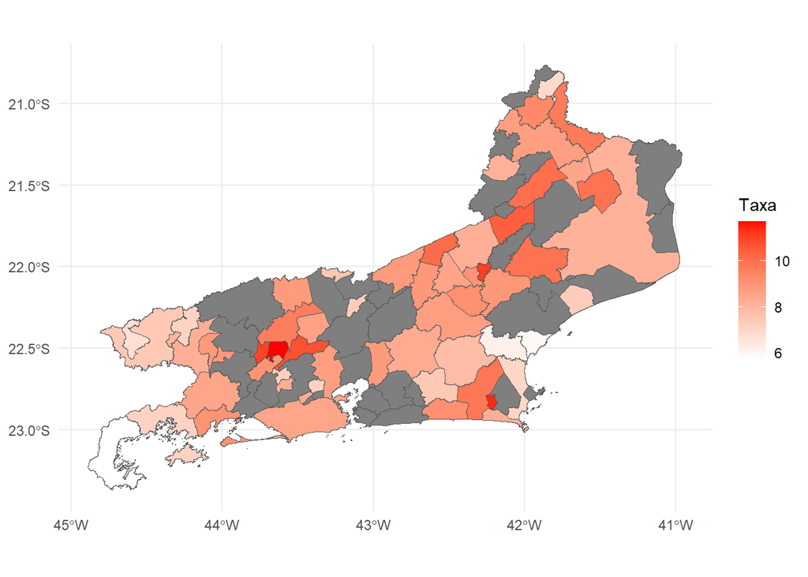

```r
# taxa de mortalidade por município RJ
taxa_shape %>%
  ggplot(aes(fill=Total)) +
  geom_sf()+
  scale_fill_gradient(name = "Taxa",
                      low = "white",  # gradiente manual
                      high = "red")+
  theme_minimal()
```

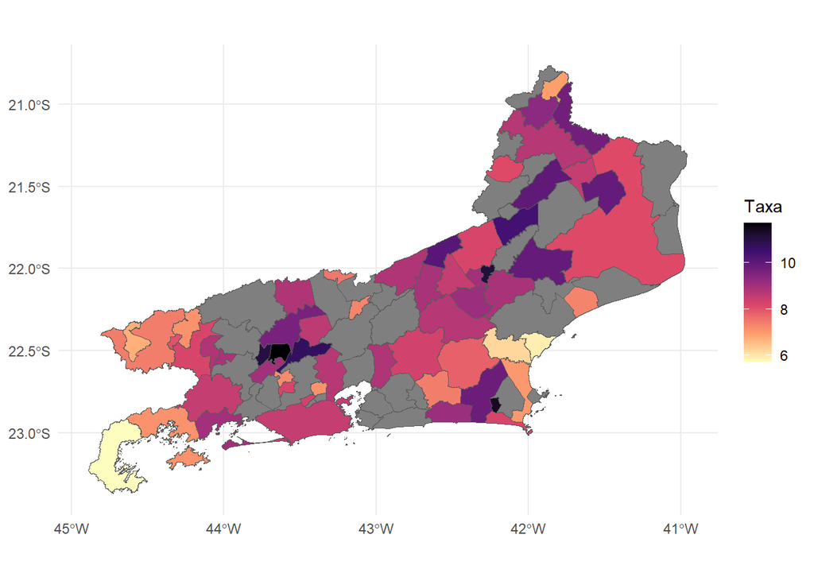

```r
taxa_shape %>%
  ggplot(aes(fill=Total)) +
  geom_sf()+
  scale_fill_viridis_c(name='Taxa',
                       option = "magma", # paletas modernas para variaveis contínuas
                       direction= -1)+ # invertendo a ordem das cores
  theme_minimal()
```

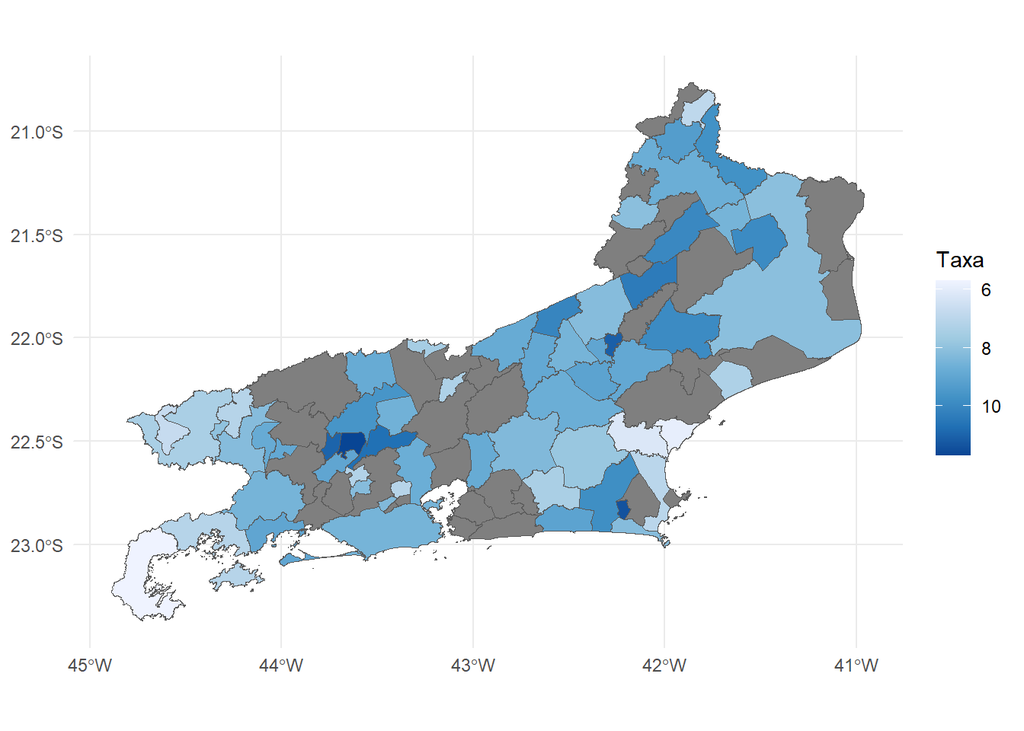

```r
taxa_shape %>%
  ggplot(aes(fill=Total)) +
  geom_sf()+
  scale_fill_distiller(name = 'Taxa',
                       palette = "Blues",  # paletas pré-definidas
                       trans = "reverse")+ # invertendo os valores
  theme_minimal()
```

# **Criação de mapas com tmap**

Outra forma de fazer mapas temáticos no R é usando as funções do pacote `tmap`. Este pacote, além de criar mapas estáticos, também é utilizado parar criar mapas interativos. As funções possuem uma sintaxe simples, similar ao `ggplot2`.

```r
# Instalando e carregando o pacote tmap
if (!require("tmap")) install.packages("tmap")
library(tmap)
```

Para plotar um mapa utilizando `tmap`, as funções essenciais são:

- `tm_shape()` : Define a camada espacial a ser utilizada para plotar o mapa. O argumento deverá ser uma base de dados com informação geoespacial.
- `tm_polygon()` : Define os limites e preenche os polígonos.
- `tm_borders()` : Adiciona as bordas do mapa.
- `tm_fill()` : Peenche a cor dos polígonos sem adição da borda.

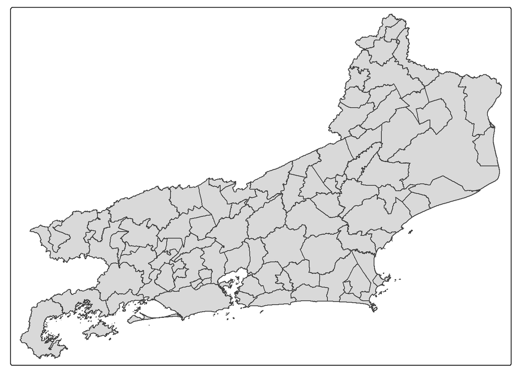

```r
# Mapa inicial
tm_shape(shp = taxa_shape) + tm_polygons()
```

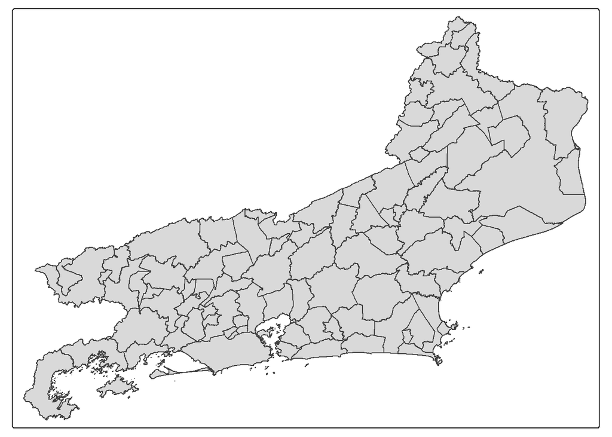

```r
# Outra maneira de plotar o mesmo mapa
tm_shape(shp = taxa_shape) + tm_fill() + tm_borders()
```

## **Mapas Coropléticos com `tmap`**

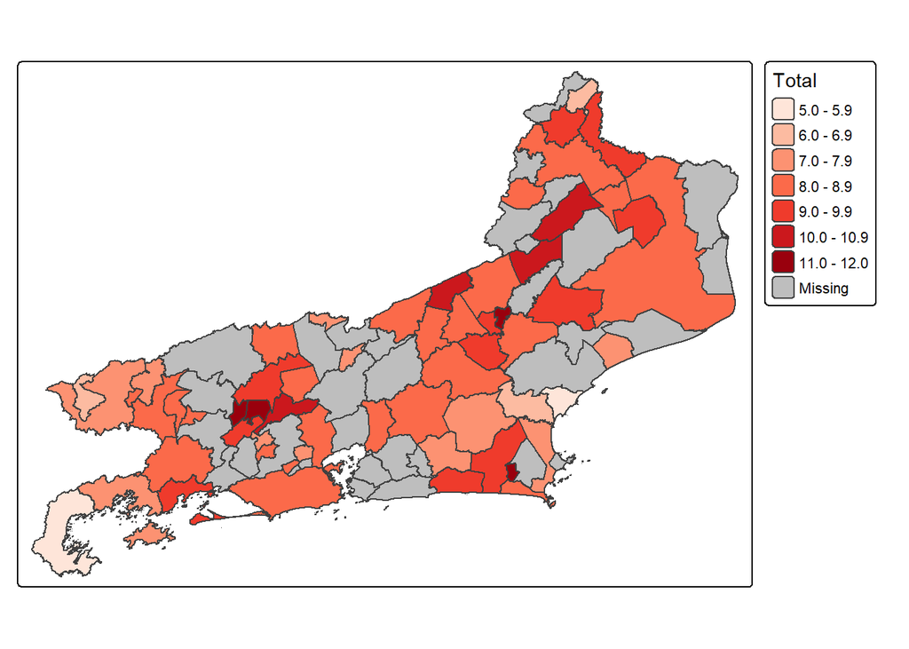

```r
tm_shape(shp = taxa_shape) + tm_fill(col = "Total", palette = "Reds") + tm_borders()
```

Existem várias formas (automáticas ou manuais) para preencher um mapa. Dentro da função utilizada para colorir o mapa, é possível utilizar os seguintes argumentos para customizá-lo da maneira que preferir:

- `style = pretty` : Configuração padrão da função. Arredonda os limites dos intervalos para números inteiros;
- `style = equal` : Divide a variável em intervalos de comprimentos iguais;
- `style = quantile` : Divide a variável em quantis;
- `style = jenks` : Identifica grupos com valores semelhantes e maximiza a diferença entre eles;
- `style = cont` : Exibe várias cores em uma paleta contínua;
- `style = cat` : Colore cada categoria individualmente para dados categóricos;
- `n` : Define o número de intervalos;
- `breaks` : Forma manual de definir os intervalos.

```r
equal = tm_shape(shp = taxa_shape) + tm_borders(col = "gray10") + tm_fill(col = "Total",
    palette = "Reds", style = "equal")

quantile = tm_shape(shp = taxa_shape) + tm_borders(col = "gray10") + tm_fill(col = "Total",
    palette = "Reds", style = "quantile")

jenks = tm_shape(shp = taxa_shape) + tm_borders(col = "gray10") + tm_fill(col = "Total",
    palette = "Reds", style = "jenks")

cont = tm_shape(shp = taxa_shape) + tm_borders(col = "gray10") + tm_fill(col = "Total",
    palette = "Reds", style = "cont")

n = tm_shape(shp = taxa_shape) + tm_borders(col = "gray10") + tm_fill(col = "Total",
    palette = "Reds", n = 4)

breaks = tm_shape(shp = taxa_shape) + tm_borders(col = "gray10") + tm_fill(col = "Total",
    palette = "Reds", breaks = c(0, 3, 6, 9, max(taxa_shape$Total)))

# tmap_arrange(equal,quantile,jenks,cont,n,breaks, ncol =3)
```

Outras funções úteis do `tmap` para detalhar os mapas:

- tm_lines(): Adiciona linhas ao mapa
- tm_dots(): Adiciona pontos ao mapa
- tm_text(): Adiciona rótulos de texto
- tm_layout(): Personaliza o layout geral
- tm_legend(): Controla a aparência da legenda
- tm_scale_bar(): Adiciona uma barra de escala
- tm_compass(): Adiciona uma rosa dos ventos
- tm_bubbles(): Adiciona uma camada de bolhas

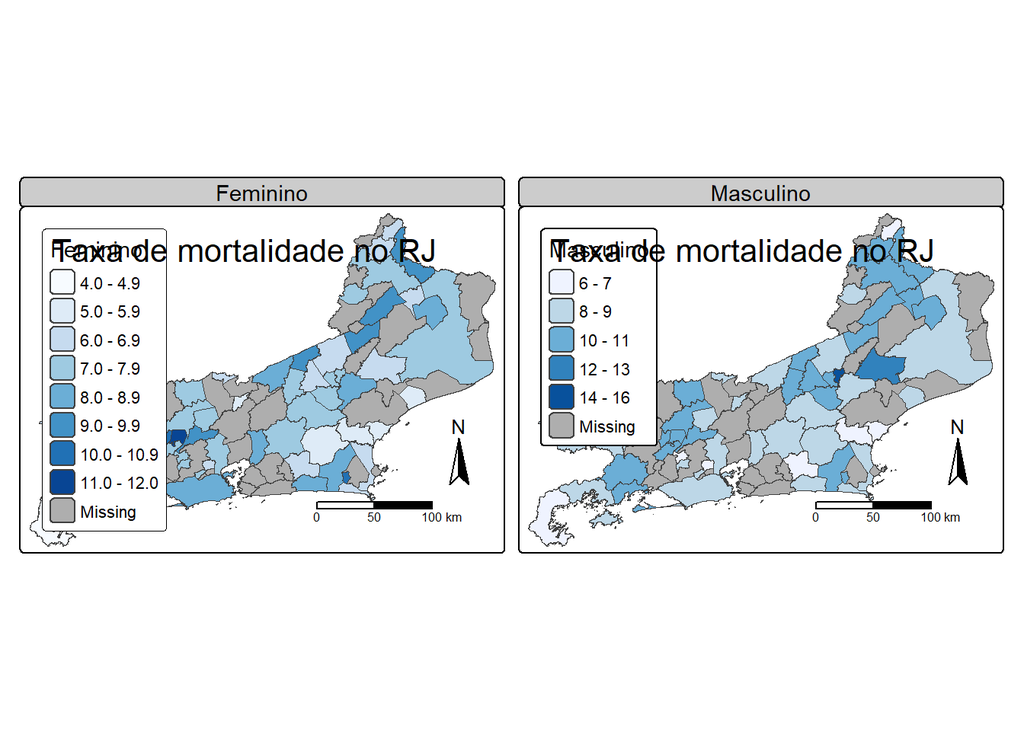

```r
# Exemplo de mapa com alguma das funções acima
tm_shape(shp = taxa_shape) + tm_fill(col = c("Feminino", "Masculino"), palette = "Blues") +
    tm_borders() + tm_layout(panel.labels = c("Feminino", "Masculino")) + tm_compass() +
    tm_scale_bar() + tm_layout(title = "Taxa de mortalidade no RJ", legend.position = c("left",
    "top"))
```

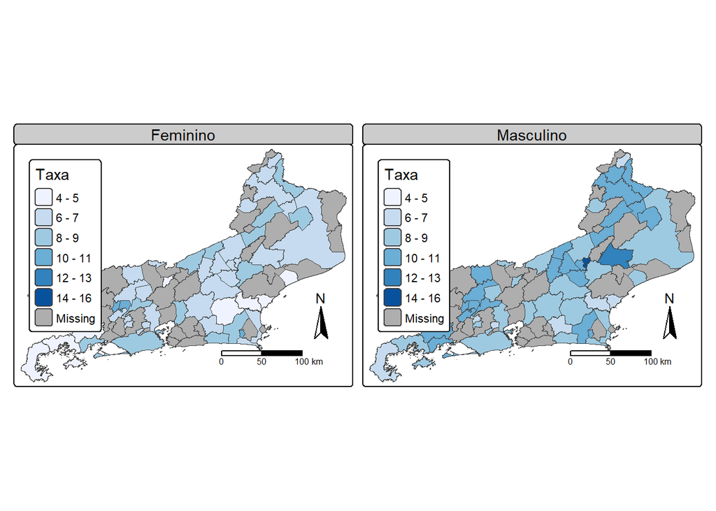

```r
# Com escalas iguais
tm_shape(shp = taxa_shape) + tm_fill(col = c("Feminino", "Masculino"), palette = "Blues",
    title = "Taxa") + tm_borders() + tm_layout(panel.labels = c("Feminino", "Masculino")) +
    tm_facets(free.scales = FALSE) + tm_compass() + tm_scale_bar() + tm_layout(legend.position = c("left",
    "top"))
```

## **Interatividade com `tmap_mode()`**

Para ativar interatividade em um mapa feito com o pacote `tmap`,basta utilizar o comando `tmap_mode("view")`. Caso prefira retornar ao modo estático, use `tmap_mode("plot")`.

```r
# Modo interativo:
tmap_mode("view")

# Especificando as informacoes que aparecem nos popups tm_shape(shp =
# taxa_shape)+ tm_borders(col='gray10')+ tm_fill(col='Total',palette =
# 'Reds',style='cont',title= 'Taxa', popup.vars = c('Municipio'='NM_MUN', 'Taxa
# total'='Total', 'Taxa feminina'='Feminino', 'Taxa masculina'='Masculino',
# 'Area km2'='AREA_KM2'), id = 'NM_MUN')+ tm_layout(title = 'Taxa de
# mortalidade no RJ')

# Voltando ao modo estatico
tmap_mode("plot")
```

# **Criação de mapas com Leaflet**

O pacote `leaflet` permite criar mapas dinâmicos e interativos no R. A construção dos mapas é feita em camadas com a utilização do operador pipe `%>%`. Primeiro, instale e carregue a biblioteca.

```r
if (!require("leaflet")) install.packages("leaflet")
library(leaflet)
```

A estrutura inicial será a função `leaflet()` que prepara a interface vazia do mapa e em seguida virá `addTiles()` que adiciona a camada base com referências visuais (como ruas e bairros) além de permitir zoom e navegação pelo mapa.

Para delimitar um espaço, pode-se utilizar `addPolygons()` e inserir o objeto sf como argumento.

> Observação: Segundo a [documentação](https://rstudio.github.io/leaflet/articles/projections.html), as bases precisam fornecer dados em WGS 84 longitude/latitude para marcadores,círculos, polígonos e linhas.

```r
#transformando o crs
bairros_wgs84 = st_transform(bairros, crs = 4326)

#plotando o mapa com leaflet
leaflet() %>%
  addTiles() %>%
  addPolygons(data = bairros_wgs84, # objeto sf com polígonos
              weight = 1, # grossura das bordas em pixels
              opacity = 0.5, # transparência das bordas
              fillOpacity = 0.2, # transparência do preenchimento
              color = "red") # cor dos polígonos e das bordas
```

[interactive chart not shown]

## **Pontos de Interesse**

Para adicionar pontos de interesse, podemos inserir como argumento o objeto sf com a informação dos pontos nas seguintes funções:

- `addMarkers()` : Adiciona marcadores com ícones;
- `addCircleMarkers()` : Adiciona marcadores em círculos com cores e tamanho modificáveis.

```r
# Mapa com as escolas em marcadores
leaflet() %>%
    addTiles() %>%
    addPolygons(data = bairros_wgs84, weight = 1, opacity = 0.5, fillOpacity = 0.2,
        color = "red") %>%
    addMarkers(data = pontos_nit)
```

[interactive chart not shown]

```r
# Mapa com as escolas em círculos
leaflet() %>%
    addTiles() %>%
    addPolygons(data = bairros_wgs84, weight = 1, opacity = 0.5, fillOpacity = 0.2,
        color = "red") %>%
    addCircleMarkers(data = pontos_latlong, radius = 5, color = "blue")
```

[interactive chart not shown]

## **Configurando pop ups e labels**

As informações importantes sobre algum ponto ou região podem ser inseridas dentro do mapa através dos pop ups (aparecem quando clicam em um ponto,polígono,marcador,etc) e/ou dos labels (aparecem ao passar o mouse em cima da geometria).

```r
leaflet() %>%
  addTiles() %>%
  addPolygons(data = bairros_wgs84,
              weight = 1,
              opacity = 0.5,
              fillOpacity = 0.2,
              color = "red",
              label = ~paste('Bairro:',tx_nome), # informação quando passar o mouse no polígono
              popup = ~paste('Bairro:',tx_nome,'<br>',
                             'Área:',Shape__Are,'<br>', # informação quando clicar no polígono
                             'Comprimento:',Shape__Len)) %>%
  addCircleMarkers(data = pontos_latlong,
                   radius = 5,
                   color = "blue",
                   label = ~paste('Escola:',tx_escola), # informação quando clicar no círculo
                   popup = ~paste('Turno:',tx_turno,'<br>', # informação quando clicar no círculo
                                  'Modalidade:',tx_modalidade))
```

[interactive chart not shown]